1.30e-01

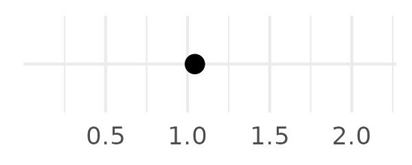

75th percentile

470,849

405

0.97 (0.88-1.1)

5.30e-01

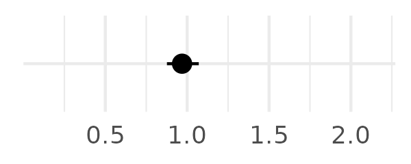

90th percentile

147,845

83

0.75 (0.6-0.93)

8.10e-03

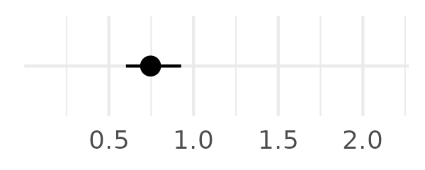

atc_group: C09 (agents acting on the renin-angiotensin system)

no use

34,127,144

10,184

1.0 (ref)

>2 prescr.

2,748,962

1,853

1.1 (1-1.1)

4.90e-02

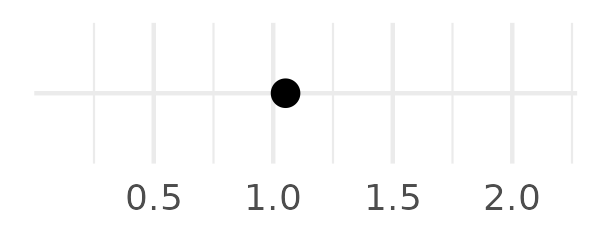

25th percentile

2,746,811

1,818

0.9 (0.86-0.95)

6.70e-05

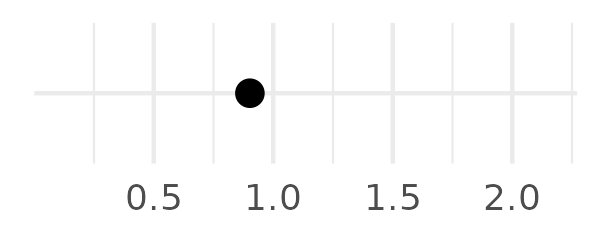

50th percentile

1,917,893

1,431

0.87 (0.83-0.92)

2.70e-06

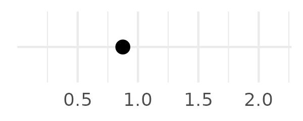

75th percentile

592,305

485

0.85 (0.78-0.93)

5.70e-04

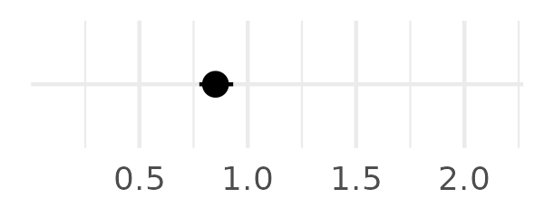

90th percentile

159,701

69

0.49 (0.38-0.62)

2.40e-09

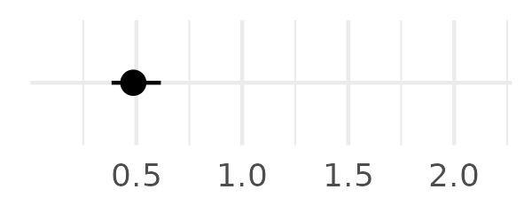

atc_group: D01 (antifungals for dermatological use)

no use

39,693,243

14,327

1.0 (ref)

>2 prescr.

10,924

0

1.6e-05 (2.2e-97-1.2e+87)

9.20e-01

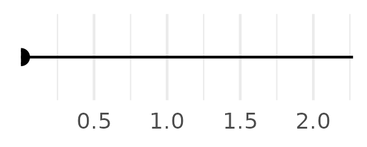

25th percentile

1,267,365

696

1.2 (1.1-1.3)

4.20e-06

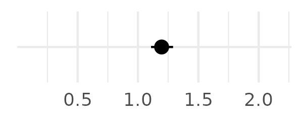

50th percentile

571,228

348

1.2 (1.1-1.4)

1.60e-04

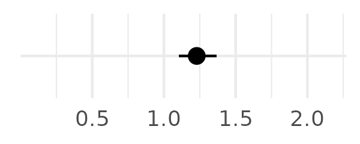

75th percentile

535,040

342

1.2 (1.1-1.3)

1.90e-03

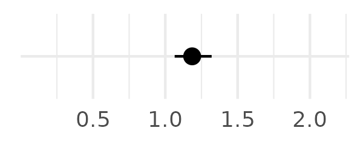

90th percentile

215,015

127

0.96 (0.81-1.1)

6.60e-01

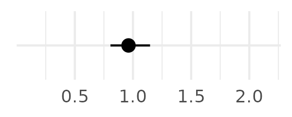

atc_group: G03 (sex hormones and modulators of the genital system)

no use

34,253,116

13,673

1.0 (ref)

>2 prescr.

1,845,965

481

1.2 (1.1-1.3)

1.70e-03

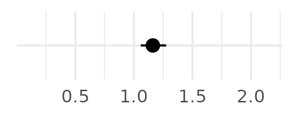

25th percentile

2,908,602

743

1.2 (1.1-1.3)

2.40e-04

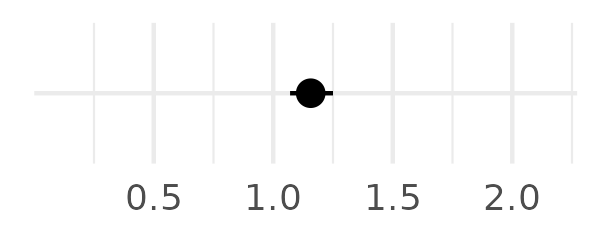

50th percentile

2,087,963

547

1 (0.95-1.1)

3.60e-01

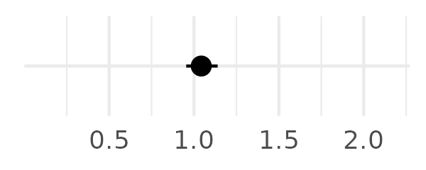

75th percentile

896,099

286

1 (0.9-1.1)

8.20e-01

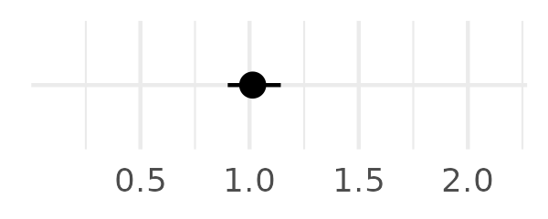

90th percentile

301,070

110

0.95 (0.78-1.1)

5.70e-01

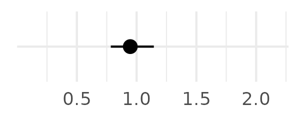

atc_group: G04 (urologicals)

no use

38,702,552

11,885

1.0 (ref)

>2 prescr.

997,317

885

1.4 (1.3-1.5)

1.30e-17

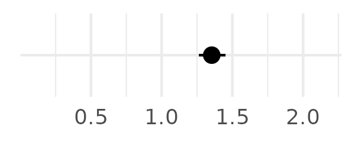

25th percentile

979,236

1,131

1.6 (1.5-1.7)

7.70e-51

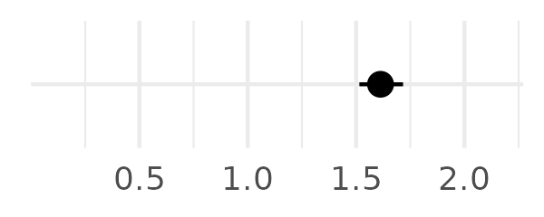

50th percentile

979,057

1,188

1.5 (1.4-1.6)

5.00e-41

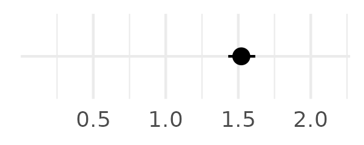

75th percentile

449,466

551

1.4 (1.3-1.5)

1.90e-13

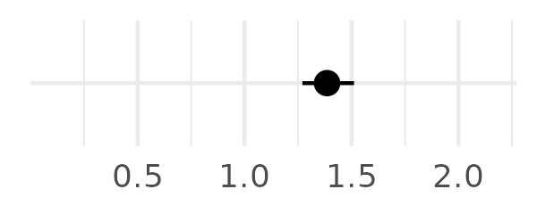

90th percentile

185,187

200

1.2 (1.1-1.4)

3.00e-03

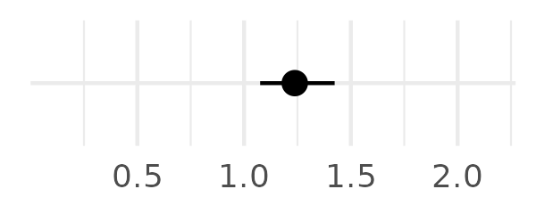

atc_group: H01 (pituitary and hypothalamic hormones and analogues)

no use

41,932,195

15,742

1.0 (ref)

>2 prescr.

1,845

0

0.00012 (6e-123-2.3e+114)